# EasyVisa Project

## Context:

Business communities in the United States are facing high demand for human resources, but one of the constant challenges is identifying and attracting the right talent, which is perhaps the most important element in remaining competitive. Companies in the United States look for hard-working, talented, and qualified individuals both locally as well as abroad.

The Immigration and Nationality Act (INA) of the US permits foreign workers to come to the United States to work on either a temporary or permanent basis. The act also protects US workers against adverse impacts on their wages or working conditions by ensuring US employers' compliance with statutory requirements when they hire foreign workers to fill workforce shortages. The immigration programs are administered by the Office of Foreign Labor Certification (OFLC).

OFLC processes job certification applications for employers seeking to bring foreign workers into the United States and grants certifications in those cases where employers can demonstrate that there are not sufficient US workers available to perform the work at wages that meet or exceed the wage paid for the occupation in the area of intended employment.

## Objective:

In FY 2016, the OFLC processed 775,979 employer applications for 1,699,957 positions for temporary and permanent labor certifications. This was a nine percent increase in the overall number of processed applications from the previous year. The process of reviewing every case is becoming a tedious task as the number of applicants is increasing every year.

The increasing number of applicants every year calls for a Machine Learning based solution that can help in shortlisting the candidates having higher chances of VISA approval. OFLC has hired your firm EasyVisa for data-driven solutions. You as a data scientist have to analyze the data provided and, with the help of a classification model:

- Facilitate the process of visa approvals.
- Recommend a suitable profile for the applicants for whom the visa should be certified or denied based on the drivers that significantly influence the case status.

## Data Description

The data contains the different attributes of the employee and the employer. The detailed data dictionary is given below.

- case_id: ID of each visa application
- continent: Information of continent the employee
- education_of_employee: Information of education of the employee
- has_job_experience: Does the employee has any job experience? Y= Yes; N = No
- requires_job_training: Does the employee require any job training? Y = Yes; N = No
- no_of_employees: Number of employees in the employer's company
- yr_of_estab: Year in which the employer's company was established
- region_of_employment: Information of foreign worker's intended region of employment in the US.
- prevailing_wage: Average wage paid to similarly employed workers in a specific occupation in the area of intended employment. The purpose of the prevailing wage is to ensure that the foreign worker is not underpaid compared to other workers offering the same or similar service in the same area of employment.
- unit_of_wage: Unit of prevailing wage. Values include Hourly, Weekly, Monthly, and Yearly.
- full_time_position: Is the position of work full-time? Y = Full Time Position; N = Part Time Position
- case_status: Flag indicating if the Visa was certified or denied

## Importing necessary libraries and data

```python
# Library to suppress warnings or deprecation notes
import warnings
warnings.filterwarnings('ignore')

# Libraries to help with reading and manipulating data
import numpy as np
import pandas as pd

# Libraries to help with data visualization
import matplotlib.pyplot as plt
%matplotlib inline
import seaborn as sns

# Library to split data
from sklearn.model_selection import train_test_split

# Libraries to import decision tree classifier and different ensemble classifiers
from sklearn.ensemble import BaggingClassifier
from sklearn.ensemble import RandomForestClassifier
from sklearn.tree import DecisionTreeClassifier
from sklearn import tree
from sklearn.linear_model import LogisticRegression

# Libtune to tune model, get different metric scores
from sklearn import metrics
from sklearn.metrics import confusion_matrix, classification_report, accuracy_score, precision_score, recall_score,f1_score,roc_auc_score
from sklearn.model_selection import GridSearchCV

from sklearn.ensemble import AdaBoostClassifier, GradientBoostingClassifier
#To install xgboost library use - !pip install xgboost
from xgboost import XGBClassifier
from xgboost import XGBRegressor

from sklearn.ensemble import StackingClassifier
```

```python
data=pd.read_csv("EasyVisa.csv")
```

```python
# copying data to another varaible to avoid any changes to original data
df=data.copy()
```

## Data Overview

- Observations
- Sanity checks

### View the first and last 5 rows of the dataset.

```python
df.head()
```

|  | case_id | continent | education_of_employee | has_job_experience | requires_job_training | no_of_employees | yr_of_estab | region_of_employment | prevailing_wage | unit_of_wage | full_time_position | case_status |
| --- | --- | --- | --- | --- | --- | --- | --- | --- | --- | --- | --- | --- |
| 0 | EZYV01 | Asia | High School | N | N | 14513 | 2007 | West | 592.2029 | Hour | Y | Denied |
| 1 | EZYV02 | Asia | Master's | Y | N | 2412 | 2002 | Northeast | 83425.6500 | Year | Y | Certified |
| 2 | EZYV03 | Asia | Bachelor's | N | Y | 44444 | 2008 | West | 122996.8600 | Year | Y | Denied |
| 3 | EZYV04 | Asia | Bachelor's | N | N | 98 | 1897 | West | 83434.0300 | Year | Y | Denied |
| 4 | EZYV05 | Africa | Master's | Y | N | 1082 | 2005 | South | 149907.3900 | Year | Y | Certified |

```python
df.tail()
```

|  | case_id | continent | education_of_employee | has_job_experience | requires_job_training | no_of_employees | yr_of_estab | region_of_employment | prevailing_wage | unit_of_wage | full_time_position | case_status |
| --- | --- | --- | --- | --- | --- | --- | --- | --- | --- | --- | --- | --- |
| 25475 | EZYV25476 | Asia | Bachelor's | Y | Y | 2601 | 2008 | South | 77092.57 | Year | Y | Certified |
| 25476 | EZYV25477 | Asia | High School | Y | N | 3274 | 2006 | Northeast | 279174.79 | Year | Y | Certified |
| 25477 | EZYV25478 | Asia | Master's | Y | N | 1121 | 1910 | South | 146298.85 | Year | N | Certified |
| 25478 | EZYV25479 | Asia | Master's | Y | Y | 1918 | 1887 | West | 86154.77 | Year | Y | Certified |
| 25479 | EZYV25480 | Asia | Bachelor's | Y | N | 3195 | 1960 | Midwest | 70876.91 | Year | Y | Certified |

### Understand the shape of the dataset.

```python
df.shape
```

```
(25480, 12)
```

- The dataset has 25480 rows and 12 columns.

```python
# checking for duplicate values in the data
df.duplicated().sum()
```

```
0
```

- There are no duplicates in the dataset

### Check the data types of the columns for the dataset.

```python
df.info()
```

```
<class 'pandas.core.frame.DataFrame'>
RangeIndex: 25480 entries, 0 to 25479
Data columns (total 12 columns):
 #   Column                 Non-Null Count  Dtype
---  ------                 --------------  -----
 0   case_id                25480 non-null  object
 1   continent              25480 non-null  object
 2   education_of_employee  25480 non-null  object
 3   has_job_experience     25480 non-null  object
 4   requires_job_training  25480 non-null  object
 5   no_of_employees        25480 non-null  int64
 6   yr_of_estab            25480 non-null  int64
 7   region_of_employment   25480 non-null  object
 8   prevailing_wage        25480 non-null  float64
 9   unit_of_wage           25480 non-null  object
 10  full_time_position     25480 non-null  object
 11  case_status            25480 non-null  object
dtypes: float64(1), int64(2), object(9)
memory usage: 2.3+ MB
```

**Observations**

- All variables are object, int, or float types - 3 variables are numeric, the remaining 9 variables are of object type.
- There are no missing values in the dataset.
- The memory usage is 2.3+ MB

```python
# Converting the columns with an 'object' data type into categorical variables
for feature in df.columns: # Loop through all columns in the dataframe
    if df[feature].dtype == 'object': # Only apply for columns with categorical strings
        df[feature] = pd.Categorical(df[feature])# Replace strings with an integer
df.info()
```

```
<class 'pandas.core.frame.DataFrame'>
RangeIndex: 25480 entries, 0 to 25479
Data columns (total 12 columns):
 #   Column                 Non-Null Count  Dtype
---  ------                 --------------  -----
 0   case_id                25480 non-null  category
 1   continent              25480 non-null  category
 2   education_of_employee  25480 non-null  category
 3   has_job_experience     25480 non-null  category
 4   requires_job_training  25480 non-null  category
 5   no_of_employees        25480 non-null  int64
 6   yr_of_estab            25480 non-null  int64
 7   region_of_employment   25480 non-null  category
 8   prevailing_wage        25480 non-null  float64
 9   unit_of_wage           25480 non-null  category
 10  full_time_position     25480 non-null  category
 11  case_status            25480 non-null  category
dtypes: category(9), float64(1), int64(2)
memory usage: 2.0 MB
```

**Observations**

- Object type columns are now category type
- Memory usage is 2.0 MB

```python
df.describe().T
```

|  | count | mean | std | min | 25% | 50% | 75% | max |
| --- | --- | --- | --- | --- | --- | --- | --- | --- |
| no_of_employees | 25480.0 | 5667.043210 | 22877.928848 | -26.0000 | 1022.00 | 2109.00 | 3504.0000 | 602069.00 |
| yr_of_estab | 25480.0 | 1979.409929 | 42.366929 | 1800.0000 | 1976.00 | 1997.00 | 2005.0000 | 2016.00 |
| prevailing_wage | 25480.0 | 74455.814592 | 52815.942327 | 2.1367 | 34015.48 | 70308.21 | 107735.5125 | 319210.27 |

#### Observations

- The mean number of employees is 5667, the min is -26 employees (negative employees will be handled below), the max is 602,069.
- The median year of establishment is 1997, the most recent year is 2016, and the earlieast (min) is 1800.
- The prevailing wage values within the same column have different units, so numbers like mean and median don't give a lot of insight.

```python
# filtering object type columns
df.describe(include=["category"])
```

|  | case_id | continent | education_of_employee | has_job_experience | requires_job_training | region_of_employment | unit_of_wage | full_time_position | case_status |
| --- | --- | --- | --- | --- | --- | --- | --- | --- | --- |
| count | 25480 | 25480 | 25480 | 25480 | 25480 | 25480 | 25480 | 25480 | 25480 |
| unique | 25480 | 6 | 4 | 2 | 2 | 5 | 4 | 2 | 2 |
| top | EZYV01 | Asia | Bachelor's | Y | N | Northeast | Year | Y | Certified |
| freq | 1 | 16861 | 10234 | 14802 | 22525 | 7195 | 22962 | 22773 | 17018 |

```python
print(df.continent.value_counts())
print(df.education_of_employee.value_counts())
print(df.has_job_experience.value_counts())
print(df.requires_job_training.value_counts())
print(df.region_of_employment.value_counts())
print(df.unit_of_wage.value_counts())
print(df.full_time_position.value_counts())
print(df.case_status.value_counts())
```

```
Asia             16861
Europe            3732
North America     3292
South America      852
Africa             551
Oceania            192
Name: continent, dtype: int64
Bachelor's     10234
Master's        9634
High School     3420
Doctorate       2192
Name: education_of_employee, dtype: int64
Y    14802
N    10678
Name: has_job_experience, dtype: int64
N    22525
Y     2955
Name: requires_job_training, dtype: int64
Northeast    7195
South        7017
West         6586
Midwest      4307
Island        375
Name: region_of_employment, dtype: int64
Year     22962
Hour      2157
Week       272
Month       89
Name: unit_of_wage, dtype: int64
Y    22773
N     2707
Name: full_time_position, dtype: int64
Certified    17018
Denied        8462
Name: case_status, dtype: int64
```

#### Observations

- Each case_id is unique.
- the continent column contains 6 unique values: Asia, Europe, N. America, S. America, Africa, and Oceania. Asia is the most frequent with 16,861 occurences.
- There are 4 different employee education levels. Of the levels, Bachelor's is the most common.
- The column has_job_experience contains either 'Y' or 'N' values with 'Y' being more common than 'N'.
- The column requires_job_training contains either 'Y' or 'N' values with 'N' being much more common than 'Y'.
- There are 5 US regions of employment, the Northeast is the most common.
- There are four units of wage: year, hour, week, and month. Year is the most common unit of wage.
- The full_time_position column contains either 'Y' or 'N' values with 'Y' being much more common than 'N'.
- The case_status column contains 2 unique values, either Certified or Denied. Certified is more common than Denied.

## Exploratory Data Analysis (EDA)

### Univariate analysis

```python
def labeled_barplot(data, feature, hue=None, perc=False, n=None, r=90):
    """
    Barplot with percentage at the top

    data: dataframe
    feature: dataframe column
    perc: whether to display percentages instead of count (default is False)
    n: displays the top n category levels (default is None, i.e., display all levels)
    """

    total = len(data[feature])  # length of the column
    count = data[feature].nunique()
    if n is None:
        plt.figure(figsize=(count + 1, 5))
    else:
        plt.figure(figsize=(n + 1, 5))
    plt.xticks(rotation=r, fontsize=15)
    if hue is None:
        ax = sns.countplot(
            data=data,
            x=feature,
            palette="Paired",
            order=data[feature].value_counts().index,
        )
    else:
        ax = sns.countplot(
            data=data,
            x=feature,
            hue=hue,
            palette="Paired",
            order=data[feature].value_counts().index,
        )
        sns.move_legend(ax, "upper left", bbox_to_anchor=(1, 1))  # legend placement
    for p in ax.patches:
        if perc == True:
            label = "{:.1f}%".format(
                100 * p.get_height() / total
            )  # percentage of each class of the category
        else:
            label = p.get_height()  # count of each level of the category

        x = p.get_x() + p.get_width() / 2  # width of the plot
        y = p.get_height()  # height of the plot

        ax.annotate(
            label,
            (x, y),
            ha="center",
            va="center",
            size=12,
            xytext=(0, 5),
            textcoords="offset points",
        )  # annotate the percentage
    plt.show()  # show the plot
```

### Observations on Continent

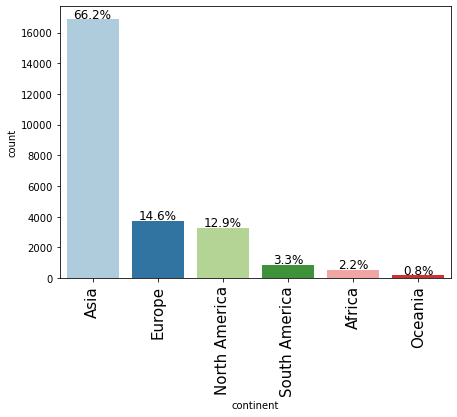

```python
labeled_barplot(df, "continent", perc=True)
```

- Most (66.2%) of the VISA applicants are from Asia.
- The next most common continents are Europe and North America with 14.6% and 12.9% respectively.
- The smallest fraction of applicants are from Oceania at 0.8%.

### Observations on Education of Employee

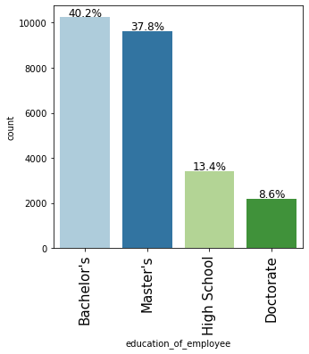

```python
labeled_barplot(df, "education_of_employee", perc=True)
```

- The most common education level is Bachelor's degree (40.2%).
- Bachelor's degree is closely followed by Master's degree 37.8%
- 13.4% have a High School diploma and 8.6% have a Doctorate.

### Observations on Has Job Experience

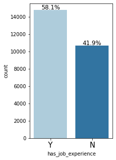

```python
labeled_barplot(df, "has_job_experience", perc=True, r=0)
```

- 58.1% of VISA applicants have job experience.
- 41.9% of VISA applicants do not have job experience.

### Observations on Requires Job Training

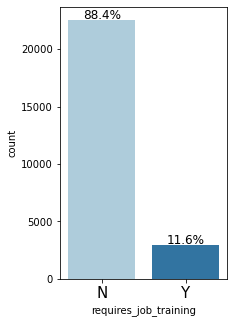

```python
labeled_barplot(df, "requires_job_training", perc=True, r=0)
```

- 88.4% of applicants do not require job taining.
- 11.6% do require job taining.

```python
# function to plot a boxplot and a histogram along the same scale.


def histogram_boxplot(data, feature, figsize=(12, 7), kde=False, bins=None):
    """
    Boxplot and histogram combined

    data: dataframe
    feature: dataframe column
    figsize: size of figure (default (12,7))
    kde: whether to show the density curve (default False)
    bins: number of bins for histogram (default None)
    """
    f2, (ax_box2, ax_hist2) = plt.subplots(
        nrows=2,  # Number of rows of the subplot grid= 2
        sharex=True,  # x-axis will be shared among all subplots
        gridspec_kw={"height_ratios": (0.25, 0.75)},
        figsize=figsize,
    )  # creating the 2 subplots
    sns.boxplot(
        data=data, x=feature, ax=ax_box2, showmeans=True, color="violet"
    )  # boxplot will be created and a star will indicate the mean value of the column
    sns.histplot(
        data=data, x=feature, kde=kde, ax=ax_hist2, bins=bins, palette="winter"
    ) if bins else sns.histplot(
        data=data, x=feature, kde=kde, ax=ax_hist2
    )  # For histogram
    ax_hist2.axvline(
        data[feature].mean(), color="green", linestyle="--"
    )  # Add mean to the histogram
    ax_hist2.axvline(
        data[feature].median(), color="black", linestyle="-"
    )  # Add median to the histogram
```

### Observations on Number of Employees

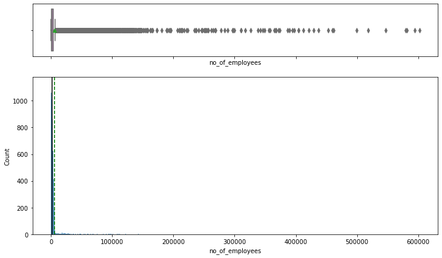

```python
histogram_boxplot(df, "no_of_employees")
```

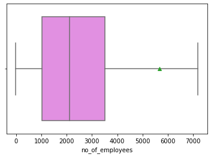

```python
sns.boxplot(data=df, x="no_of_employees", showmeans=True,  showfliers=False, color="violet");
```

```python
df.no_of_employees.describe()
```

```
count     25480.000000
mean       5667.043210
std       22877.928848
min         -26.000000
25%        1022.000000
50%        2109.000000
75%        3504.000000
max      602069.000000
Name: no_of_employees, dtype: float64
```

- The distribution of number of employees is right skewed.
- There are several outliers on the high end.
- The median is 2109 employes and the mean is 5667 employees.

### Observations on Year of Establishment

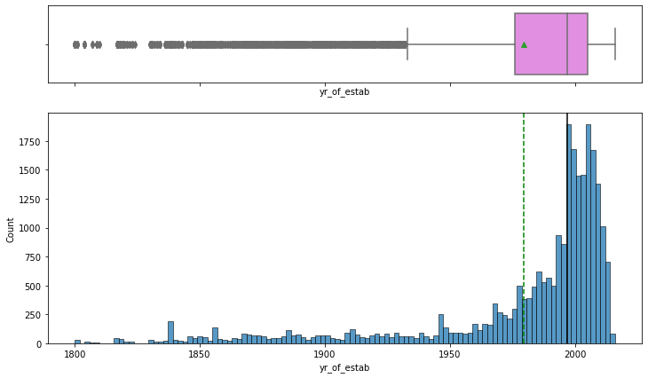

```python
histogram_boxplot(df, "yr_of_estab", figsize=(12, 7), kde=False, bins=None)
```

- The year of establishment distribution is left skewed
- Most companies were established after 1950.

### Observations on Region of Employment

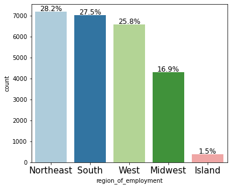

```python
labeled_barplot(df, "region_of_employment", perc=True, r=0)
```

- The top three regions are the northeast (28.2%), the south (27.5%), and the west (25.8%).
- The midwest is the 4th most popular region of the 5 regions.
- Island is the least popular region of employment.

### Observations on Prevailing Wage

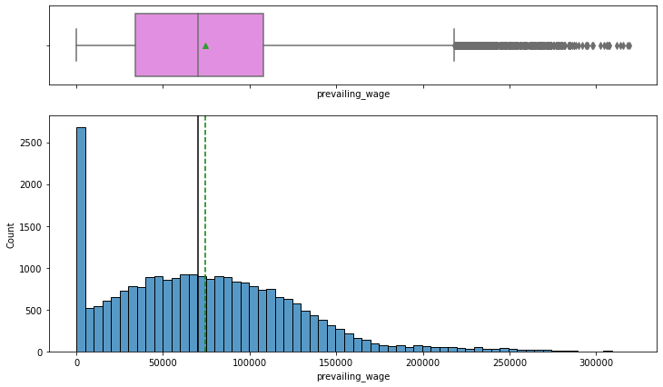

```python
histogram_boxplot(df, "prevailing_wage", figsize=(12, 7), kde=False, bins=None)
```

- The prevailing wage has a spike just above 0, likely due to the hourly wages.
- There are several ouliers on the high wage side.

### Observations on Unit of Wage

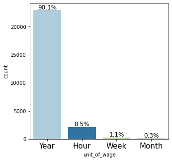

```python
labeled_barplot(df, "unit_of_wage", perc=True, r=0)
```

- Most commonly, the wage is a yearly wage (90.1%).
- 8.5% of the entries have an hourly wage.
- 1.1% are weekly unit of wage, and the remaining 0.3% are monthly.

### Observations on Full Time Position

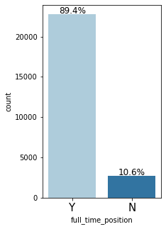

```python
labeled_barplot(df, "full_time_position", perc=True, r=0)
```

- 89.4% of the VISA applications are associated with full time position and 10.6% are not.

### Observations on Case Status

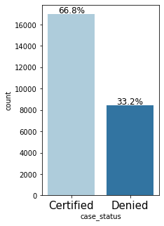

```python
labeled_barplot(df, "case_status", perc=True, r=0)
```

- 66.8% of the applications were certified and 33.2% were denied.

## Bivariate Analysis

**Leading Questions**:

1. Those with higher education may want to travel abroad for a well-paid job. Does education play a role in Visa certification?
2. How does the visa status vary across different continents?
3. Experienced professionals might look abroad for opportunities to improve their lifestyles and career development. Does work experience influence visa status?
4. In the United States, employees are paid at different intervals. Which pay unit is most likely to be certified for a visa?
5. The US government has established a prevailing wage to protect local talent and foreign workers. How does the visa status change with the prevailing wage?

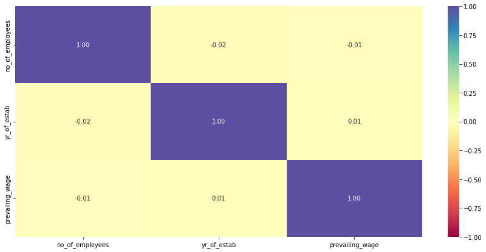

```python
plt.figure(figsize=(15, 7))
sns.heatmap(data.corr(), annot=True, vmin=-1, vmax=1, fmt=".2f", cmap="Spectral")
plt.show()
```

**Observations**

- There is essentially no correlation between number of employees, prevailing wage, and year of establishment.

```python
# function to plot stacked bar chart


def stacked_barplot(data, predictor, target):
    """
    Print the category counts and plot a stacked bar chart

    data: dataframe
    predictor: independent variable
    target: target variable
    """
    count = data[predictor].nunique()
    sorter = data[target].value_counts().index[-1]
    tab1 = pd.crosstab(data[predictor], data[target], margins=True).sort_values(
        by=sorter, ascending=False
    )
    print(tab1)
    print("-" * 120)
    tab = pd.crosstab(data[predictor], data[target], normalize="index").sort_values(
        by=sorter, ascending=False
    )
    tab.plot(kind="bar", stacked=True, figsize=(count + 5, 6))
    plt.legend(
        loc="lower left", frameon=False,
    )
    plt.legend(loc="upper left", bbox_to_anchor=(1, 1))
    plt.show()
```

```python
### function to plot distributions wrt target


def distribution_plot_wrt_target(data, predictor, target):

    fig, axs = plt.subplots(2, 2, figsize=(12, 10))

    target_uniq = data[target].unique()

    axs[0, 0].set_title("Distribution of target for target=" + str(target_uniq[0]))
    sns.histplot(
        data=data[data[target] == target_uniq[0]],
        x=predictor,
        kde=True,
        ax=axs[0, 0],
        color="teal",
        stat="density",
    )

    axs[0, 1].set_title("Distribution of target for target=" + str(target_uniq[1]))
    sns.histplot(
        data=data[data[target] == target_uniq[1]],
        x=predictor,
        kde=True,
        ax=axs[0, 1],
        color="orange",
        stat="density",
    )

    axs[1, 0].set_title("Boxplot w.r.t target")
    sns.boxplot(data=data, x=target, y=predictor, ax=axs[1, 0], palette="gist_rainbow")

    axs[1, 1].set_title("Boxplot (without outliers) w.r.t target")
    sns.boxplot(
        data=data,
        x=target,
        y=predictor,
        ax=axs[1, 1],
        showfliers=False,
        palette="gist_rainbow",
    )

    plt.tight_layout()
    plt.show()
```

```python
### Function to plot boxplot
def boxplot(x):
    plt.figure(figsize=(10,7))
    sns.boxplot(data=df, x="case_status",y=df[x],palette="PuBu")
    plt.show()
```

### Question 1: Those with higher education may want to travel abroad for a well-paid job. Does education play a role in Visa certification?

```
case_status            Certified  Denied    All
education_of_employee
All                        17018    8462  25480
Bachelor's                  6367    3867  10234
High School                 1164    2256   3420
Master's                    7575    2059   9634
Doctorate                   1912     280   2192
------------------------------------------------------------------------------------------------------------------------
```

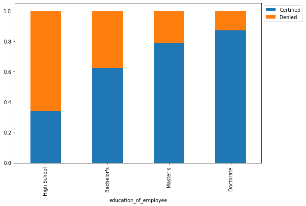

```python
stacked_barplot(df,'education_of_employee', 'case_status')
```

```
education_of_employee  Bachelor's  Doctorate  High School  Master's    All
case_status
All                         10234       2192         3420      9634  25480
Certified                    6367       1912         1164      7575  17018
Denied                       3867        280         2256      2059   8462
------------------------------------------------------------------------------------------------------------------------
```

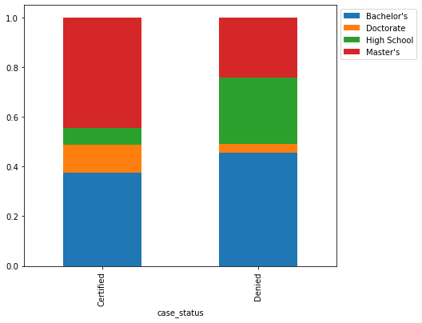

```python
stacked_barplot(df,'case_status','education_of_employee')
```

- Most applicants with a Doctorate are certified - about 90%.
- About 80% of applicants with a Master's are certified.
- There are more applicants with a Master's than a Doctorate and the largest portion of applicants who are certified have a Master's.
- The next largest portion of applicants who are certificed have a Bachelor's.
- About 2/3 of applicants with a Bachelor's are certified.
- More applicants with High School education are denied than certified.

### Question 2: How does the visa status vary across different continents?

```
case_status    Certified  Denied    All
continent
All                17018    8462  25480
Asia               11012    5849  16861
North America       2037    1255   3292
Europe              2957     775   3732
South America        493     359    852
Africa               397     154    551
Oceania              122      70    192
------------------------------------------------------------------------------------------------------------------------
```

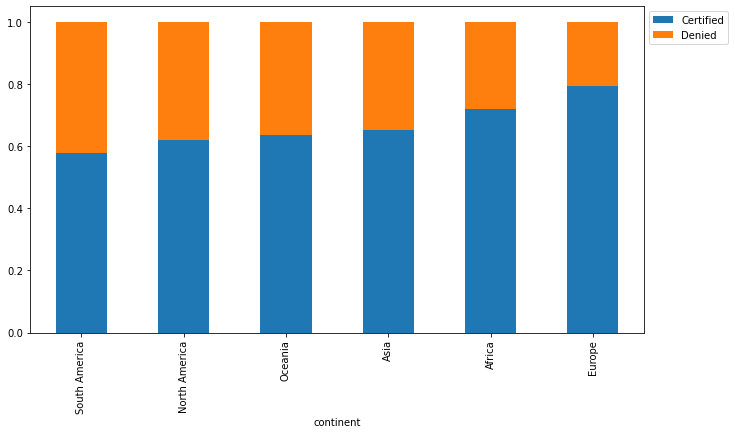

```python
stacked_barplot(df,'continent','case_status')
```

```
continent    Africa   Asia  Europe  North America  Oceania  South America  \
case_status
All             551  16861    3732           3292      192            852
Certified       397  11012    2957           2037      122            493
Denied          154   5849     775           1255       70            359

continent      All
case_status
All          25480
Certified    17018
Denied        8462
------------------------------------------------------------------------------------------------------------------------
```

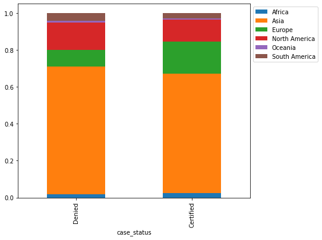

```python
stacked_barplot(df,'case_status','continent')
```

### Question 3: Experienced professionals might look abroad for opportunities to improve their lifestyles and career development. Does work experience influence visa status?

```
case_status         Certified  Denied    All
has_job_experience
All                     17018    8462  25480
N                        5994    4684  10678
Y                       11024    3778  14802
------------------------------------------------------------------------------------------------------------------------
```

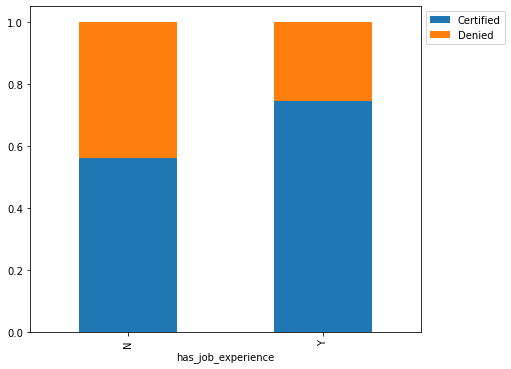

```python
stacked_barplot(df,'has_job_experience','case_status')
```

- A larger fraction of applicants with job experience are certified than those without job experience.

### Observations on requires job training and case status

```
case_status            Certified  Denied    All
requires_job_training
All                        17018    8462  25480
N                          15012    7513  22525
Y                           2006     949   2955
------------------------------------------------------------------------------------------------------------------------
```

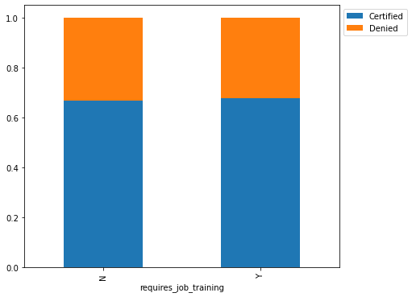

```python
stacked_barplot(df,'requires_job_training','case_status')
```

- Certification status appears to be independent of whether job training is required. In each case, about 2/3 of applications are certified.

### Observations on region and case status

```
case_status           Certified  Denied    All
region_of_employment
All                       17018    8462  25480
Northeast                  4526    2669   7195
West                       4100    2486   6586
South                      4913    2104   7017
Midwest                    3253    1054   4307
Island                      226     149    375
------------------------------------------------------------------------------------------------------------------------
```

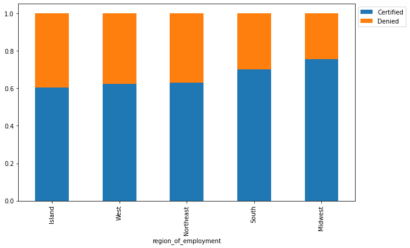

```python
stacked_barplot(df,'region_of_employment','case_status');
```

- The greatest proportion of applicants are certified for jobs in the midwest.

### Question 4: In the United States, employees are paid at different intervals. Which pay unit is most likely to be certified for a visa?

```
case_status   Certified  Denied    All
unit_of_wage
All               17018    8462  25480
Year              16047    6915  22962
Hour                747    1410   2157
Week                169     103    272
Month                55      34     89
------------------------------------------------------------------------------------------------------------------------
```

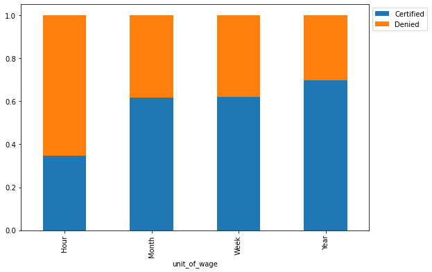

```python
stacked_barplot(df,'unit_of_wage','case_status')
```

- Applicants associated with jobs that report a yearly pay interval have the highest fraction of certified applicants.
- Those with a monthly and weekly unit of wage have a very similar fraction of applicants that are certified.
- Hourly has the smallest fraction certified.

### Observations on full time position and certification status

```
case_status         Certified  Denied    All
full_time_position
All                     17018    8462  25480
Y                       15163    7610  22773
N                        1855     852   2707
------------------------------------------------------------------------------------------------------------------------
```

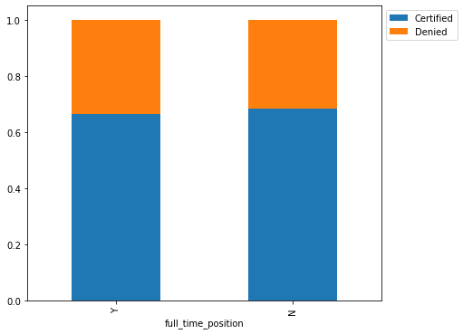

```python
stacked_barplot(df,'full_time_position','case_status')
```

- The proportion of applications certified is similar for full time and part time positions.

### Observations on number of employees and certification status

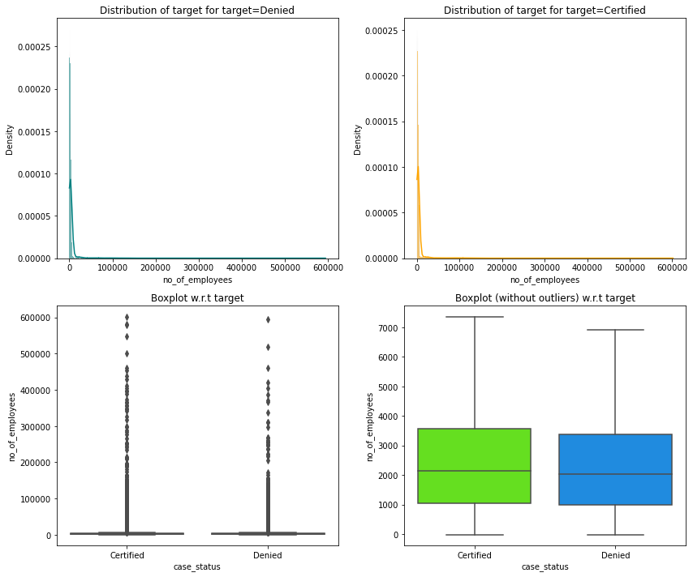

```python
distribution_plot_wrt_target(df,"no_of_employees", "case_status")
```

- The median number of employees is slightly greater among companies with certified applicants.

### Observations on year of establishment and certification status

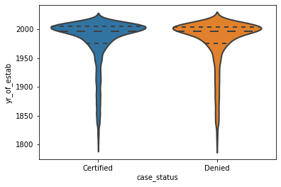

```python
sns.violinplot(data=df, x="case_status", y="yr_of_estab", inner="quart", linewidth=2);
```

- The distribution of year the company was established is similar among certified and denied applications.

### Question 5: The US government has established a prevailing wage to protect local talent and foreign workers. How does the visa status change with the prevailing wage?

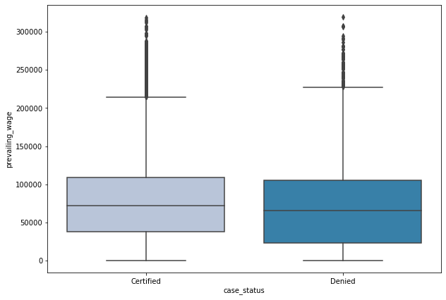

```python
boxplot('prevailing_wage')
```

```python
status = df.groupby('case_status').prevailing_wage
status.describe()
```

| case_status | count | mean | std | min | 25% | 50% | 75% | max |
| --- | --- | --- | --- | --- | --- | --- | --- | --- |
| Certified | 17018.0 | 77293.619243 | 52042.715576 | 2.1367 | 38375.330 | 72486.27 | 108879.1075 | 318446.05 |
| Denied | 8462.0 | 68748.681580 | 53890.166031 | 2.9561 | 23497.295 | 65431.46 | 105097.6400 | 319210.27 |

- Overall, it appears that denied applicants have a lower prevailing wage.

### Observations on unit of wage, prevailing wage, and certification status

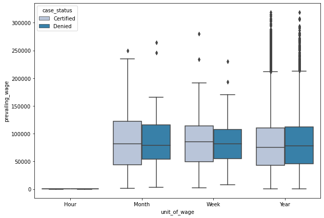

```python
plt.figure(figsize=(10,7))
sns.boxplot(data=df, x="unit_of_wage",y='prevailing_wage', hue='case_status', palette="PuBu")
plt.show()
```

- For each unit_of_wage group, the median prevailing wage of accepted and denied candidates is fairly similar.
- The median monthly, weekly, and yearly prevailing wage are quite similar. Each of the medians are around $75,000.
- Hourly prevailing wage is much less.
- It is likely that applications with weekly, monthly, and yearly unit of wage report prevailing wage in terms of yearly wages, and those that receive hourly pay report prevailing wage in terms of hourly or weekly wages.

## Data Preprocessing

```python
df.isnull().sum()
```

```
case_id                  0
continent                0
education_of_employee    0
has_job_experience       0
requires_job_training    0
no_of_employees          0
yr_of_estab              0
region_of_employment     0
prevailing_wage          0
unit_of_wage             0
full_time_position       0
case_status              0
dtype: int64
```

- There are no missing values.

### Treatment of no_of_employees < 0

```python
negEmployees = df[df['no_of_employees']<0]
negEmployees.shape
```

```
(33, 12)
```

```python
negEmployees.head(33)
```

|  | case_id | continent | education_of_employee | has_job_experience | requires_job_training | no_of_employees | yr_of_estab | region_of_employment | prevailing_wage | unit_of_wage | full_time_position | case_status |
| --- | --- | --- | --- | --- | --- | --- | --- | --- | --- | --- | --- | --- |
| 245 | EZYV246 | Europe | Master's | N | N | -25 | 1980 | Northeast | 39452.9900 | Year | Y | Certified |
| 378 | EZYV379 | Asia | Bachelor's | N | Y | -11 | 2011 | Northeast | 32506.1400 | Year | Y | Denied |
| 832 | EZYV833 | South America | Master's | Y | N | -17 | 2002 | South | 129701.9400 | Year | Y | Certified |
| 2918 | EZYV2919 | Asia | Master's | Y | N | -26 | 2005 | Midwest | 112799.4600 | Year | Y | Certified |
| 6439 | EZYV6440 | Asia | Bachelor's | N | N | -14 | 2013 | South | 103.9700 | Hour | Y | Denied |
| 6634 | EZYV6635 | Asia | Bachelor's | Y | N | -26 | 1923 | West | 5247.3200 | Year | Y | Denied |
| 7224 | EZYV7225 | Europe | Doctorate | N | N | -25 | 1998 | Midwest | 141435.9500 | Year | Y | Certified |
| 7281 | EZYV7282 | Asia | High School | N | N | -14 | 2000 | Midwest | 58488.5000 | Year | Y | Denied |
| 7318 | EZYV7319 | Asia | Bachelor's | Y | Y | -26 | 2006 | South | 115005.6100 | Year | Y | Certified |
| 7761 | EZYV7762 | Asia | Master's | N | N | -11 | 2009 | Midwest | 38457.5100 | Year | Y | Certified |
| 9872 | EZYV9873 | Europe | Master's | Y | N | -26 | 1996 | South | 37397.0500 | Year | Y | Certified |
| 11493 | EZYV11494 | Asia | High School | Y | N | -14 | 1999 | South | 27599.3500 | Year | Y | Denied |
| 13471 | EZYV13472 | North America | Master's | N | N | -17 | 2003 | Northeast | 257.2413 | Hour | Y | Denied |
| 14022 | EZYV14023 | Asia | Bachelor's | N | Y | -11 | 1946 | Northeast | 108403.5600 | Year | Y | Certified |
| 14146 | EZYV14147 | Asia | Bachelor's | N | Y | -26 | 1954 | West | 81982.2700 | Year | Y | Certified |
| 14726 | EZYV14727 | Asia | Master's | N | N | -11 | 2000 | Midwest | 167851.8000 | Year | Y | Certified |
| 15600 | EZYV15601 | Asia | Bachelor's | N | N | -14 | 2014 | South | 24641.6100 | Year | Y | Denied |
| 15859 | EZYV15860 | Asia | High School | N | N | -11 | 1969 | South | 44640.6000 | Year | Y | Denied |
| 16157 | EZYV16158 | Asia | Master's | Y | N | -11 | 1994 | South | 62681.2500 | Year | Y | Certified |
| 16883 | EZYV16884 | North America | Bachelor's | Y | N | -26 | 1968 | Northeast | 168.1558 | Hour | Y | Denied |
| 17006 | EZYV17007 | Asia | Doctorate | Y | N | -11 | 1984 | West | 25753.5100 | Year | Y | Denied |
| 17655 | EZYV17656 | North America | Bachelor's | Y | N | -17 | 2007 | Northeast | 129753.1800 | Year | Y | Denied |
| 17844 | EZYV17845 | Asia | Bachelor's | N | N | -14 | 2012 | West | 29325.8500 | Year | Y | Denied |
| 17983 | EZYV17984 | Asia | Bachelor's | N | N | -26 | 2004 | South | 84359.9800 | Year | Y | Denied |
| 20815 | EZYV20816 | Asia | Bachelor's | N | Y | -17 | 1990 | West | 91897.5700 | Year | Y | Certified |
| 20984 | EZYV20985 | Europe | Doctorate | Y | N | -14 | 1989 | Midwest | 37012.8000 | Year | Y | Certified |
| 21255 | EZYV21256 | North America | High School | N | N | -25 | 1987 | South | 99405.4700 | Year | N | Denied |
| 21760 | EZYV21761 | Asia | Bachelor's | Y | N | -25 | 2000 | West | 100463.5800 | Year | Y | Certified |
| 21944 | EZYV21945 | Africa | Master's | Y | N | -25 | 1977 | Midwest | 79150.5100 | Year | Y | Certified |
| 22084 | EZYV22085 | North America | Bachelor's | Y | N | -14 | 1980 | West | 691.0609 | Hour | Y | Denied |
| 22388 | EZYV22389 | Asia | Master's | Y | N | -14 | 1986 | South | 17893.1100 | Year | Y | Certified |
| 23186 | EZYV23187 | Asia | Master's | N | Y | -11 | 2007 | Midwest | 120195.3500 | Year | Y | Certified |
| 23476 | EZYV23477 | Europe | Master's | Y | N | -11 | 2000 | West | 95072.7500 | Year | Y | Denied |

- There are no clear patterns in the rows that contian a negative number of employees.
- Since the employer is not listed, it is difficult to estimate the correct number of employees.
- Since it is not possible to have negative employees, the negative sign will be dropped.

```python
df['no_of_employees'] = abs(df['no_of_employees'])
```

```python
df.describe().T
```

|  | count | mean | std | min | 25% | 50% | 75% | max |
| --- | --- | --- | --- | --- | --- | --- | --- | --- |
| no_of_employees | 25480.0 | 5667.089207 | 22877.917453 | 11.0000 | 1022.00 | 2109.00 | 3504.0000 | 602069.00 |
| yr_of_estab | 25480.0 | 1979.409929 | 42.366929 | 1800.0000 | 1976.00 | 1997.00 | 2005.0000 | 2016.00 |
| prevailing_wage | 25480.0 | 74455.814592 | 52815.942327 | 2.1367 | 34015.48 | 70308.21 | 107735.5125 | 319210.27 |

#### Outlier Treatment

- Variation will be lost if the number of employees and year of establishment outliers are removed, therefore they will be kept.
- The prevailing wage column will be dropped, so outlier treatment of prevailing wage will not be necessary.

## EDA

- It is a good idea to explore the data once again after manipulating it.

### Number of Employees

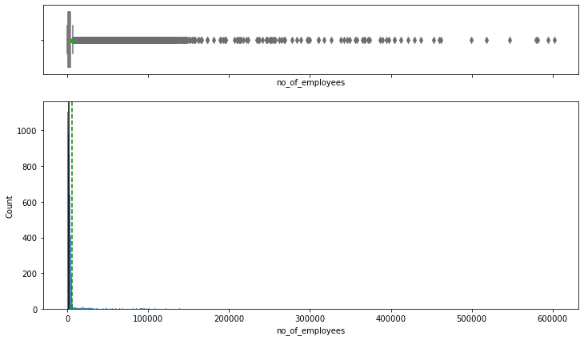

```python
histogram_boxplot(df, "no_of_employees")
```

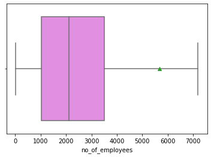

```python
sns.boxplot(data=df, x="no_of_employees", showmeans=True,  showfliers=False, color="violet");
```

```python
df.no_of_employees.describe()
```

```
count     25480.000000
mean       5667.089207
std       22877.917453
min          11.000000
25%        1022.000000
50%        2109.000000
75%        3504.000000
max      602069.000000
Name: no_of_employees, dtype: float64
```

- The no_of_employees distribution is very similar above, however there are no longer any values with a negative number of employees.

### Final preparation

```python
replaceStruct = {"education_of_employee":     {"High School": 1, "Bachelor's": 2 ,"Master's": 3 ,"Doctorate":4},
                 "full_time_position":     {"N": 1, "Y": 2},
                "has_job_experience":     {"N": 1, "Y": 2 },
                "requires_job_training":     {"N": 2, "Y": 1 },
                "case_status":     {"Denied": 0, "Certified": 1 }
                    }
```

```python
df=df.replace(replaceStruct)
df.info()
```

```
<class 'pandas.core.frame.DataFrame'>
RangeIndex: 25480 entries, 0 to 25479
Data columns (total 12 columns):
 #   Column                 Non-Null Count  Dtype
---  ------                 --------------  -----
 0   case_id                25480 non-null  category
 1   continent              25480 non-null  category
 2   education_of_employee  25480 non-null  int64
 3   has_job_experience     25480 non-null  int64
 4   requires_job_training  25480 non-null  int64
 5   no_of_employees        25480 non-null  int64
 6   yr_of_estab            25480 non-null  int64
 7   region_of_employment   25480 non-null  category
 8   prevailing_wage        25480 non-null  float64
 9   unit_of_wage           25480 non-null  category
 10  full_time_position     25480 non-null  int64
 11  case_status            25480 non-null  int64
dtypes: category(4), float64(1), int64(7)
memory usage: 2.9 MB
```

## Building bagging and boosting models

```python
# Dropping case status, case id, and prevailing wage, creating dummies
X = df.drop(['case_status',"case_id","prevailing_wage"],axis=1)
X = pd.get_dummies(X)
y = df['case_status']
```

```python
X.head()
```

|  | education_of_employee | has_job_experience | requires_job_training | no_of_employees | yr_of_estab | full_time_position | continent_Africa | continent_Asia | continent_Europe | continent_North America | ... | continent_South America | region_of_employment_Island | region_of_employment_Midwest | region_of_employment_Northeast | region_of_employment_South | region_of_employment_West | unit_of_wage_Hour | unit_of_wage_Month | unit_of_wage_Week | unit_of_wage_Year |
| --- | --- | --- | --- | --- | --- | --- | --- | --- | --- | --- | --- | --- | --- | --- | --- | --- | --- | --- | --- | --- | --- |
| 0 | 1 | 1 | 2 | 14513 | 2007 | 2 | 0 | 1 | 0 | 0 | ... | 0 | 0 | 0 | 0 | 0 | 1 | 1 | 0 | 0 | 0 |
| 1 | 3 | 2 | 2 | 2412 | 2002 | 2 | 0 | 1 | 0 | 0 | ... | 0 | 0 | 0 | 1 | 0 | 0 | 0 | 0 | 0 | 1 |
| 2 | 2 | 1 | 1 | 44444 | 2008 | 2 | 0 | 1 | 0 | 0 | ... | 0 | 0 | 0 | 0 | 0 | 1 | 0 | 0 | 0 | 1 |
| 3 | 2 | 1 | 2 | 98 | 1897 | 2 | 0 | 1 | 0 | 0 | ... | 0 | 0 | 0 | 0 | 0 | 1 | 0 | 0 | 0 | 1 |
| 4 | 3 | 2 | 2 | 1082 | 2005 | 2 | 1 | 0 | 0 | 0 | ... | 0 | 0 | 0 | 0 | 1 | 0 | 0 | 0 | 0 | 1 |

5 rows × 21 columns

```python
# Splitting data into training and test set:
X_train, X_test, y_train, y_test =train_test_split(X, y, test_size=0.3, random_state=1,stratify=y)
print(X_train.shape, X_test.shape)
```

```
(17836, 21) (7644, 21)
```

```python
y.value_counts(1)
```

```
1    0.667896
0    0.332104
Name: case_status, dtype: float64
```

```python
y_test.value_counts(1)
```

```
1    0.667844
0    0.332156
Name: case_status, dtype: float64
```

## Model evaluation criterion

### Model can make wrong predictions as:

1. False positive: Predicting an applicant will be certified for a visa, but the applicant was not certified for a visa.
2. False negative: Predicting an applicant will not be certified for a visa, but the applicant was certified for a visa.

### Which case is more important?

- In creating a model with predictive power to determine which applicants should be certified and which should be denied, both cases are important. It would be a loss of opportunity if the model filtered out well qualified applicants. But the model should also be able to reliably predict which candidates to deny. As the number of candidates continues to increase, it is possible that certification may get more competitive and emphasis will be placed on reducing false positives - not certifying candidates who would otherwise be denied.
- Priority will be placed on a high f1 score, checking that there is a balance of precision and recall.

```python
# defining a function to compute different metrics to check performance of a classification model built using sklearn
def model_performance_classification_sklearn(model, predictors, target, index):
    """
    Function to compute different metrics to check classification model performance

    model: classifier
    predictors: independent variables
    target: dependent variable
    """

    # predicting using the independent variables
    pred = model.predict(predictors)

    acc = accuracy_score(target, pred)  # to compute Accuracy
    recall = recall_score(target, pred)  # to compute Recall
    precision = precision_score(target, pred)  # to compute Precision
    f1 = f1_score(target, pred)  # to compute F1-score

    # creating a dataframe of metrics
    df_perf = pd.DataFrame(
        {
            "Accuracy": acc,
            "Recall": recall,
            "Precision": precision,
            "F1": f1,
        },
        index=[index],
    )

    return df_perf
```

```python
def confusion_matrix_sklearn(model, predictors, target):
    """
    To plot the confusion_matrix with percentages

    model: classifier
    predictors: independent variables
    target: dependent variable
    """
    y_pred = model.predict(predictors)
    cm = confusion_matrix(target, y_pred)
    labels = np.asarray(
        [
            ["{0:0.0f}".format(item) + "\n{0:.2%}".format(item / cm.flatten().sum())]
            for item in cm.flatten()
        ]
    ).reshape(2, 2)

    plt.figure(figsize=(6, 4))
    sns.heatmap(cm, annot=labels, fmt="")
    plt.ylabel("True label")
    plt.xlabel("Predicted label")
```

## Bagging

### Decision Tree Classifier

```python
#Fitting the model
dtree = DecisionTreeClassifier(random_state=1)
dtree.fit(X_train,y_train)
```

```
DecisionTreeClassifier(random_state=1)
```

|  | Accuracy | Recall | Precision | F1 |
| --- | --- | --- | --- | --- |
| Training performance | 0.999888 | 0.999832 | 1.0 | 0.999916 |

|  | Accuracy | Recall | Precision | F1 |
| --- | --- | --- | --- | --- |
| Testing performance | 0.657509 | 0.736533 | 0.747069 | 0.741764 |

```
Confusion Matrix
```

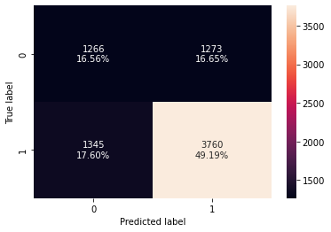

```python
dtree_model_train_perf=model_performance_classification_sklearn(dtree, X_train, y_train,'Training performance')
display(dtree_model_train_perf)

dtree_model_test_perf=model_performance_classification_sklearn(dtree, X_test, y_test, 'Testing performance')
display(dtree_model_test_perf)

print("\nConfusion Matrix")
confusion_matrix_sklearn(dtree, X_test, y_test)
```

- The decision tree is overfitting the training data as there is a large difference between training and test scores for all the metrics.

### Bagging Classifier

```python
#Fitting the model
bagging = BaggingClassifier(random_state=1)
bagging.fit(X_train,y_train)
```

```
BaggingClassifier(random_state=1)
```

```python
bagging = BaggingClassifier(random_state=1)
bagging.fit(X_train,y_train)
```

```
BaggingClassifier(random_state=1)
```

|  | Accuracy | Recall | Precision | F1 |
| --- | --- | --- | --- | --- |
| Training performance | 0.982619 | 0.983128 | 0.990779 | 0.986939 |

|  | Accuracy | Recall | Precision | F1 |
| --- | --- | --- | --- | --- |
| Testing performance | 0.69113 | 0.768462 | 0.768914 | 0.768688 |

```
Confusion Matrix
```

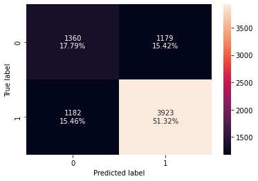

```python
bagging_model_train_perf=model_performance_classification_sklearn(bagging, X_train, y_train, 'Training performance')
display(bagging_model_train_perf)

bagging_model_test_perf=model_performance_classification_sklearn(bagging, X_test, y_test, 'Testing performance')
display(bagging_model_test_perf)

print("\nConfusion Matrix")
confusion_matrix_sklearn(bagging, X_test, y_test)
```

- The Bagging classifier is overfitting on the training set as there is a large difference between training and test performance for all the metrics.

### Random Forest

```python
rf = RandomForestClassifier(random_state=1)
rf.fit(X_train,y_train)
```

```
RandomForestClassifier(random_state=1)
```

|  | Accuracy | Recall | Precision | F1 |
| --- | --- | --- | --- | --- |
| Training performance | 0.999888 | 0.999916 | 0.999916 | 0.999916 |

|  | Accuracy | Recall | Precision | F1 |
| --- | --- | --- | --- | --- |
| Testing performance | 0.700026 | 0.806464 | 0.759314 | 0.782179 |

```
Confusion Matrix
```

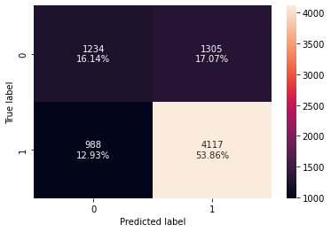

```python
rf_model_train_perf=model_performance_classification_sklearn(rf, X_train, y_train, 'Training performance')
display(rf_model_train_perf)

rf_model_test_perf=model_performance_classification_sklearn(rf, X_test, y_test, 'Testing performance')
display(rf_model_test_perf)

print("\nConfusion Matrix")
confusion_matrix_sklearn(rf, X_test, y_test)
```

- Random forest is overfitting on the training set as there is a large difference between training and test performance for all the metrics.

## Boosting

### AdaBoost Classifier

```python
abc = AdaBoostClassifier(random_state=1)
abc.fit(X_train,y_train)
```

```
AdaBoostClassifier(random_state=1)
```

|  | Accuracy | Recall | Precision | F1 |
| --- | --- | --- | --- | --- |
| Training performance | 0.737273 | 0.88693 | 0.759871 | 0.818499 |

|  | Accuracy | Recall | Precision | F1 |
| --- | --- | --- | --- | --- |
| Testing performance | 0.734956 | 0.887561 | 0.757312 | 0.81728 |

```
Confusion Matrix
```

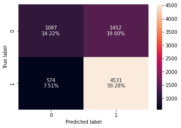

```python
abc_model_train_perf=model_performance_classification_sklearn(abc, X_train, y_train, 'Training performance')
display(abc_model_train_perf)

abc_model_test_perf=model_performance_classification_sklearn(abc, X_test, y_test, 'Testing performance')
display(abc_model_test_perf)

print("\nConfusion Matrix")
confusion_matrix_sklearn(abc, X_test, y_test)
```

- The training set and test set values are similar, indicating that the model is not overfit to the training data.
- The model resulted in high recall and f1 with reasonable precision.

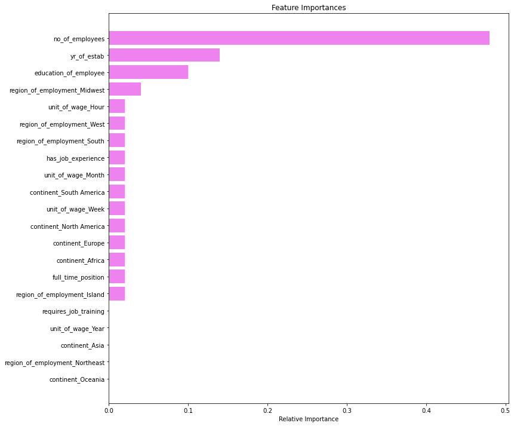

```python
feature_names = X_train.columns
importances = abc.feature_importances_
indices = np.argsort(importances)

plt.figure(figsize=(12,12))
plt.title('Feature Importances')
plt.barh(range(len(indices)), importances[indices], color='violet', align='center')
plt.yticks(range(len(indices)), [feature_names[i] for i in indices])
plt.xlabel('Relative Importance')
plt.show()
```

- In this model, number of employees is the most important feature, followed by year of establishment.
- The next most important features are education of employee and region of employment Midwest.
- The next 12 features of small equal importance after the top 4 features.

### Gradient Boosting Classifier

```python
gbc = GradientBoostingClassifier(random_state=1)
gbc.fit(X_train,y_train)
```

```
GradientBoostingClassifier(random_state=1)
```

|  | Accuracy | Recall | Precision | F1 |
| --- | --- | --- | --- | --- |
| Training performance | 0.755943 | 0.879963 | 0.781963 | 0.828074 |

|  | Accuracy | Recall | Precision | F1 |
| --- | --- | --- | --- | --- |
| Testing performance | 0.744505 | 0.87522 | 0.772476 | 0.820645 |

```
Confusion Matrix
```

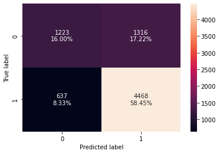

```python
gbc_model_train_perf=model_performance_classification_sklearn(gbc, X_train, y_train, 'Training performance')
display(gbc_model_train_perf)

gbc_model_test_perf=model_performance_classification_sklearn(gbc, X_test, y_test, 'Testing performance')
display(gbc_model_test_perf)

print("\nConfusion Matrix")
confusion_matrix_sklearn(gbc, X_test, y_test)
```

- This is a good model, training and test performance have high recall and f1 with reasonably high precision.
- The training set and test set values are similar.

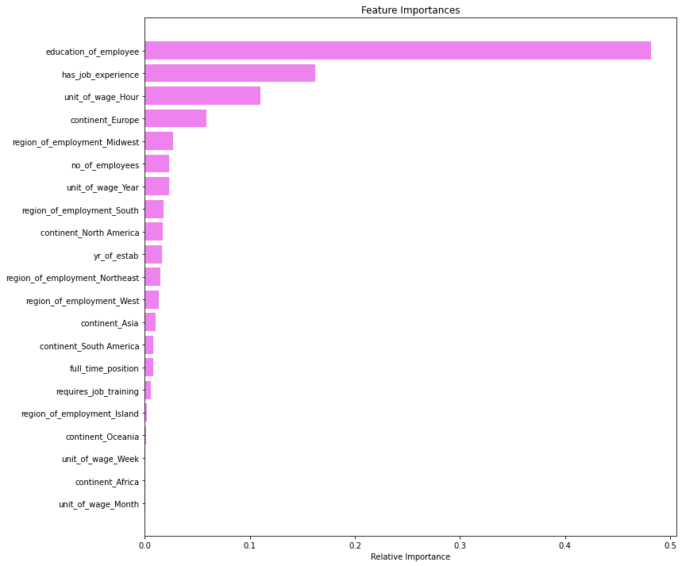

```python
feature_names = X_train.columns
importances = gbc.feature_importances_
indices = np.argsort(importances)

plt.figure(figsize=(12,12))
plt.title('Feature Importances')
plt.barh(range(len(indices)), importances[indices], color='violet', align='center')
plt.yticks(range(len(indices)), [feature_names[i] for i in indices])
plt.xlabel('Relative Importance')
plt.show()
```

- The most important feature in this model is education of employee.
- The next top features are has job experience, unit of wage Hour, continent Europe, and region of employment Midwest.

### Gradient Boosting Classifier with AdaBoost initializer

```python
gbc_init = GradientBoostingClassifier(init=AdaBoostClassifier(random_state=1),random_state=1)
gbc_init.fit(X_train,y_train)
```

```
GradientBoostingClassifier(init=AdaBoostClassifier(random_state=1),
                           random_state=1)
```

|  | Accuracy | Recall | Precision | F1 |
| --- | --- | --- | --- | --- |
| Training performance | 0.755607 | 0.879627 | 0.781782 | 0.827823 |

|  | Accuracy | Recall | Precision | F1 |
| --- | --- | --- | --- | --- |
| Testing performance | 0.743721 | 0.876004 | 0.7713 | 0.820325 |

```
Confusion Matrix
```

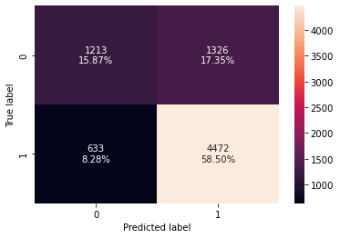

```python
gbc_init_model_train_perf=model_performance_classification_sklearn(gbc_init, X_train, y_train, 'Training performance')
display(gbc_init_model_train_perf)

gbc_init_model_test_perf=model_performance_classification_sklearn(gbc_init, X_test, y_test, 'Testing performance')
display(gbc_init_model_test_perf)

print("\nConfusion Matrix")
confusion_matrix_sklearn(gbc_init, X_test, y_test)
```

- This is a good model, the results are similar to the previous Gradient Boost model.
- Recall and F1 are good and precision is not bad.
- The training set and test set have similar results.

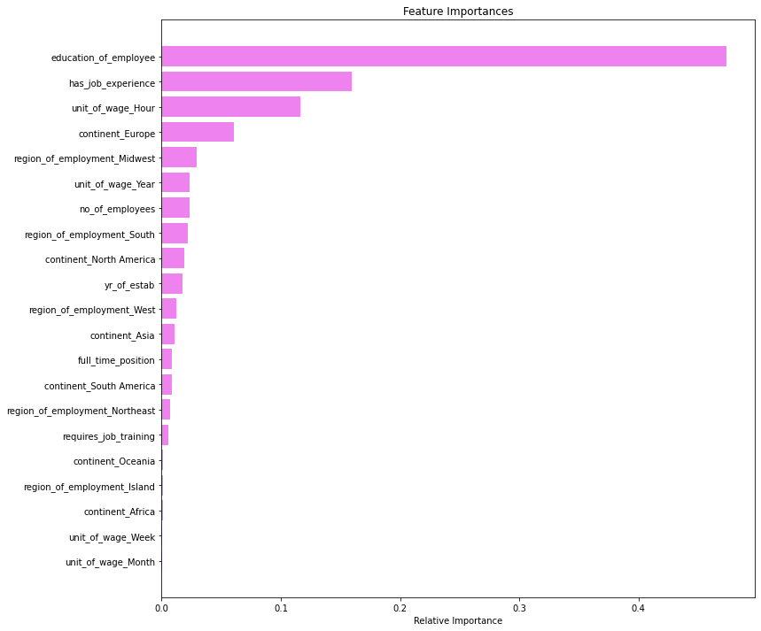

```python
feature_names = X_train.columns
importances = gbc_init.feature_importances_
indices = np.argsort(importances)

plt.figure(figsize=(12,12))
plt.title('Feature Importances')
plt.barh(range(len(indices)), importances[indices], color='violet', align='center')
plt.yticks(range(len(indices)), [feature_names[i] for i in indices])
plt.xlabel('Relative Importance')
plt.show()
```

- The top five features and the order of importance is the same for this model as the Gradient Boost model above.

### XGBoost Classifier

```python
xgb = XGBClassifier(random_state=1,eval_metric='logloss')
xgb.fit(X_train,y_train)
```

```
XGBClassifier(base_score=0.5, booster='gbtree', callbacks=None,
              colsample_bylevel=1, colsample_bynode=1, colsample_bytree=1,
              early_stopping_rounds=None, enable_categorical=False,
              eval_metric='logloss', gamma=0, gpu_id=-1,
              grow_policy='depthwise', importance_type=None,
              interaction_constraints='', learning_rate=0.300000012,
              max_bin=256, max_cat_to_onehot=4, max_delta_step=0, max_depth=6,
              max_leaves=0, min_child_weight=1, missing=nan,
              monotone_constraints='()', n_estimators=100, n_jobs=0,
              num_parallel_tree=1, predictor='auto', random_state=1,
              reg_alpha=0, reg_lambda=1, ...)
```

|  | Accuracy | Recall | Precision | F1 |
| --- | --- | --- | --- | --- |
| Training performance | 0.8207 | 0.920255 | 0.829839 | 0.872711 |

|  | Accuracy | Recall | Precision | F1 |
| --- | --- | --- | --- | --- |
| Testing performance | 0.728414 | 0.855632 | 0.765376 | 0.807991 |

```
Confusion Matrix
```

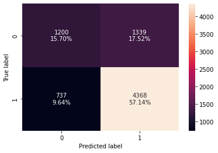

```python
xgb_model_train_perf=model_performance_classification_sklearn(xgb, X_train, y_train, 'Training performance')
display(xgb_model_train_perf)

xgb_model_test_perf=model_performance_classification_sklearn(xgb, X_test, y_test, 'Testing performance')
display(xgb_model_test_perf)

print("\nConfusion Matrix")
confusion_matrix_sklearn(xgb, X_test, y_test)
```

- This model has generally good results, but the gap between training and test performance metrics indicates that it is slightly overfit to the training data.

## Will tuning the hyperparameters improve the model performance?

## Model Improvement - Bagging

### Weighted Tuned Decision Tree

```python
# Choose the type of classifier.
dtree_estimator = DecisionTreeClassifier(class_weight={0:0.67,1:0.33},random_state=1)

# Grid of parameters to choose from
parameters = {'max_depth': np.arange(2,30),
              'min_samples_leaf': [1, 2, 5, 7, 10],
              'max_leaf_nodes' : [2, 3, 5, 10,15],
              'min_impurity_decrease': [0.0001,0.001,0.01,0.1]
             }

# Type of scoring used to compare parameter combinations
scorer = metrics.make_scorer(metrics.f1_score)

# Run the grid search
grid_obj = GridSearchCV(dtree_estimator, parameters, scoring=scorer)
grid_obj = grid_obj.fit(X_train, y_train)

# Set the clf to the best combination of parameters
dtree_estimator = grid_obj.best_estimator_

# Fit the best algorithm to the data.
dtree_estimator.fit(X_train, y_train)
```

```
DecisionTreeClassifier(class_weight={0: 0.67, 1: 0.33}, max_depth=4,
                       max_leaf_nodes=10, min_impurity_decrease=0.0001,
                       random_state=1)
```

|  | Accuracy | Recall | Precision | F1 |
| --- | --- | --- | --- | --- |
| Training performance | 0.716641 | 0.779569 | 0.792744 | 0.786101 |

|  | Accuracy | Recall | Precision | F1 |
| --- | --- | --- | --- | --- |
| Testing performance | 0.715594 | 0.78237 | 0.789796 | 0.786066 |

```
Confusion Matrix
```

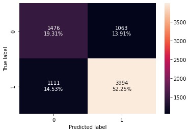

```python
dtree_estimator_model_train_perf=model_performance_classification_sklearn(dtree_estimator, X_train, y_train,'Training performance')
display(dtree_estimator_model_train_perf)

dtree_estimator_model_test_perf=model_performance_classification_sklearn(dtree_estimator, X_test, y_test, 'Testing performance')
display(dtree_estimator_model_test_perf)

print("\nConfusion Matrix")
confusion_matrix_sklearn(dtree_estimator, X_test, y_test)
```

- This is a decent model, accuracy, recall, precision, and f1 are well balanced.
- The training and test results are similar.

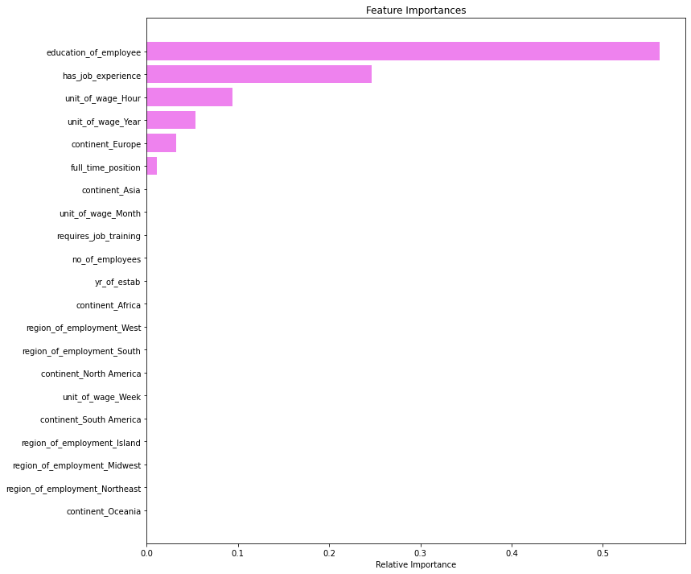

```python
feature_names = X_train.columns
importances = dtree_estimator.feature_importances_
indices = np.argsort(importances)

plt.figure(figsize=(12,12))
plt.title('Feature Importances')
plt.barh(range(len(indices)), importances[indices], color='violet', align='center')
plt.yticks(range(len(indices)), [feature_names[i] for i in indices])
plt.xlabel('Relative Importance')
plt.show()
```

- The most important features of this model are education of employee, has job experience, unit of wage hour, unit of wage year, continent Europe, and full time position.

### Tuned Bagging Classifier

```python
# Choose the type of classifier.
bagging_estimator = BaggingClassifier(random_state=1)

# Grid of parameters to choose from
## add from article
parameters = {'max_samples': [0.8,0.9,1],
              'max_features': [0.4, 0.5, 0.7],
              'n_estimators' : [10,20,30],
             }

# Type of scoring used to compare parameter combinations
acc_scorer = metrics.make_scorer(metrics.f1_score)

# Run the grid search
grid_obj = GridSearchCV(bagging_estimator, parameters, scoring=acc_scorer,cv=5)
grid_obj = grid_obj.fit(X_train, y_train)

# Set the clf to the best combination of parameters
bagging_estimator = grid_obj.best_estimator_

# Fit the best algorithm to the data.
bagging_estimator.fit(X_train, y_train)
```

```
BaggingClassifier(max_features=0.4, max_samples=1, n_estimators=20,
                  random_state=1)
```

|  | Accuracy | Recall | Precision | F1 |
| --- | --- | --- | --- | --- |
| Training performance | 0.667919 | 1.0 | 0.667919 | 0.800901 |

|  | Accuracy | Recall | Precision | F1 |
| --- | --- | --- | --- | --- |
| Testing performance | 0.667844 | 1.0 | 0.667844 | 0.800847 |

```
Confusion Matrix
```

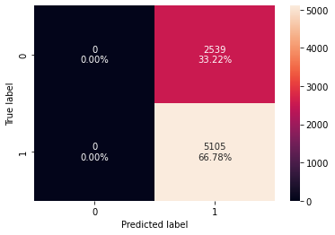

```python
bagging_estimator_model_train_perf=model_performance_classification_sklearn(bagging_estimator, X_train, y_train,'Training performance')
display(bagging_estimator_model_train_perf)

bagging_estimator_model_test_perf=model_performance_classification_sklearn(bagging_estimator, X_test, y_test, 'Testing performance')
display(bagging_estimator_model_test_perf)

print("\nConfusion Matrix")
confusion_matrix_sklearn(bagging_estimator, X_test, y_test)
```

- This model has a very high recall score.
- There is good agreement between performance on training and test sets.
- However, as can be seen by the confusion matrix, it is predicting that every applicant will be certified.

### Weighted Tuned Random Forest

```python
# Choose the type of classifier.
rf_estimator = RandomForestClassifier(random_state=1)

# Grid of parameters to choose from
## add from article
parameters = {
    "class_weight": [{0: 0.67, 1: 0.33}],
    "n_estimators": [150,200,250],
    "min_samples_leaf": np.arange(1, 6),
    "max_features": np.arange(0.1, 0.3, 0.1),
    "max_samples": np.arange(0.1, 0.2, 0.1),
}

# Type of scoring used to compare parameter combinations
acc_scorer = metrics.make_scorer(metrics.f1_score)

# Run the grid search
grid_obj = GridSearchCV(rf_estimator, parameters, scoring=acc_scorer,cv=5)
grid_obj = grid_obj.fit(X_train, y_train)

# Set the clf to the best combination of parameters
rf_estimator = grid_obj.best_estimator_

# Fit the best algorithm to the data.
rf_estimator.fit(X_train, y_train)
```

```
RandomForestClassifier(class_weight={0: 0.67, 1: 0.33}, max_features=0.1,
                       max_samples=0.1, n_estimators=250, random_state=1)
```

|  | Accuracy | Recall | Precision | F1 |
| --- | --- | --- | --- | --- |
| Training performance | 0.790928 | 0.918241 | 0.798817 | 0.854376 |

|  | Accuracy | Recall | Precision | F1 |
| --- | --- | --- | --- | --- |
| Testing performance | 0.732601 | 0.883643 | 0.756752 | 0.81529 |

```
Confusion Matrix
```

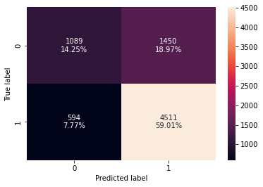

```python
rf_estimator_model_train_perf=model_performance_classification_sklearn(rf_estimator, X_train, y_train,'Training performance')
display(rf_estimator_model_train_perf)

rf_estimator_model_test_perf=model_performance_classification_sklearn(rf_estimator, X_test, y_test, 'Testing performance')
display(rf_estimator_model_test_perf)

print("\nConfusion Matrix")
confusion_matrix_sklearn(rf_estimator, X_test, y_test)
```

- This model has generally good results, but there is a small gap between training and test performance metrics that indicates that it is slightly overfit to the training data.

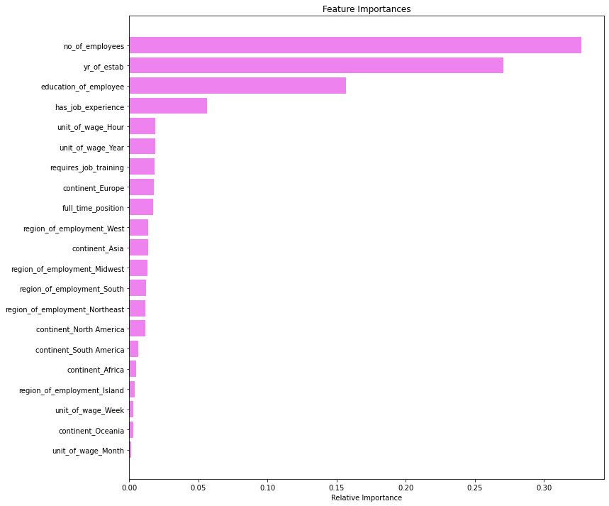

```python
importances = rf_estimator.feature_importances_
indices = np.argsort(importances)
feature_names = list(X.columns)

plt.figure(figsize=(12,12))
plt.title('Feature Importances')
plt.barh(range(len(indices)), importances[indices], color='violet', align='center')
plt.yticks(range(len(indices)), [feature_names[i] for i in indices])
plt.xlabel('Relative Importance')
plt.show()
```

## Model Improvement - Boosting

### Tuned AdaBoost

```python
# Choose the type of classifier.
abc_tuned = AdaBoostClassifier(random_state=1)

# Grid of parameters to choose from
## add from article
parameters = {
    #Let's try different max_depth for base_estimator
    "base_estimator":[DecisionTreeClassifier(max_depth=1, random_state=1),DecisionTreeClassifier(max_depth=2, random_state=1),DecisionTreeClassifier(max_depth=3, random_state=1)],
    "n_estimators": np.arange(10,40,5),
    "learning_rate":np.arange(0.05,0.2,0.05)
}

# Type of scoring used to compare parameter combinations
acc_scorer = metrics.make_scorer(metrics.f1_score)

# Run the grid search
grid_obj = GridSearchCV(abc_tuned, parameters, scoring=acc_scorer,cv=5)
grid_obj = grid_obj.fit(X_train, y_train)

# Set the clf to the best combination of parameters
abc_tuned = grid_obj.best_estimator_

# Fit the best algorithm to the data.
abc_tuned.fit(X_train, y_train)
```

```
AdaBoostClassifier(base_estimator=DecisionTreeClassifier(max_depth=1,
                                                         random_state=1),
                   learning_rate=0.05, n_estimators=25, random_state=1)
```

|  | Accuracy | Recall | Precision | F1 |
| --- | --- | --- | --- | --- |
| Training performance | 0.691803 | 0.971628 | 0.691706 | 0.808113 |

|  | Accuracy | Recall | Precision | F1 |
| --- | --- | --- | --- | --- |
| Testing performance | 0.689953 | 0.971988 | 0.690221 | 0.807223 |

```
Confusion Matrix
```

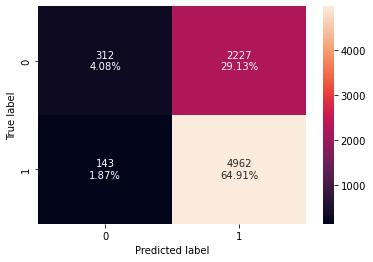

```python
abc_tuned_estimator_model_train_perf=model_performance_classification_sklearn(abc_tuned, X_train, y_train,'Training performance')
display(abc_tuned_estimator_model_train_perf)

abc_tuned_estimator_model_test_perf=model_performance_classification_sklearn(abc_tuned, X_test, y_test, 'Testing performance')
display(abc_tuned_estimator_model_test_perf)

print("\nConfusion Matrix")
confusion_matrix_sklearn(abc_tuned, X_test, y_test)
```

- The recall score is high for train and test with this model.
- There is good agreement between performance on training and test sets.
- However, the false positives are (29%) are too high, leading to a lower precision score than several of the other models.

### Tuned Gradient Boost with AdaBoost Initializer

```python
# Choose the type of classifier.
gbc_tuned = GradientBoostingClassifier(init=AdaBoostClassifier(random_state=1),random_state=1)

# Grid of parameters to choose from
## add from article
parameters = {
    "n_estimators": [100,150,200,250],
    "subsample":[0.7,0.8,0.9],
    "max_features":[0.8,0.9,1]
}

# Type of scoring used to compare parameter combinations
acc_scorer = metrics.make_scorer(metrics.f1_score)

# Run the grid search
grid_obj = GridSearchCV(gbc_tuned, parameters, scoring=acc_scorer,cv=5)
grid_obj = grid_obj.fit(X_train, y_train)

# Set the clf to the best combination of parameters
gbc_tuned = grid_obj.best_estimator_

# Fit the best algorithm to the data.
gbc_tuned.fit(X_train, y_train)
```

```
GradientBoostingClassifier(init=AdaBoostClassifier(random_state=1),
                           max_features=1, random_state=1, subsample=0.8)
```

|  | Accuracy | Recall | Precision | F1 |
| --- | --- | --- | --- | --- |
| Training performance | 0.739852 | 0.911861 | 0.751609 | 0.824016 |

|  | Accuracy | Recall | Precision | F1 |
| --- | --- | --- | --- | --- |
| Testing performance | 0.728153 | 0.905779 | 0.743289 | 0.816528 |

```
Confusion Matrix
```

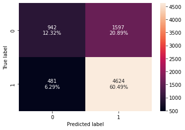

```python
gbc_tuned_estimator_model_train_perf=model_performance_classification_sklearn(gbc_tuned, X_train, y_train,'Training performance')
display(gbc_tuned_estimator_model_train_perf)

gbc_tuned_estimator_model_test_perf=model_performance_classification_sklearn(gbc_tuned, X_test, y_test, 'Testing performance')
display(gbc_tuned_estimator_model_test_perf)

print("\nConfusion Matrix")
confusion_matrix_sklearn(gbc_tuned, X_test, y_test)
```

- With this model, recall and f1 for train and test are good, precision is reasonable.
- The training set and test set values are similar.

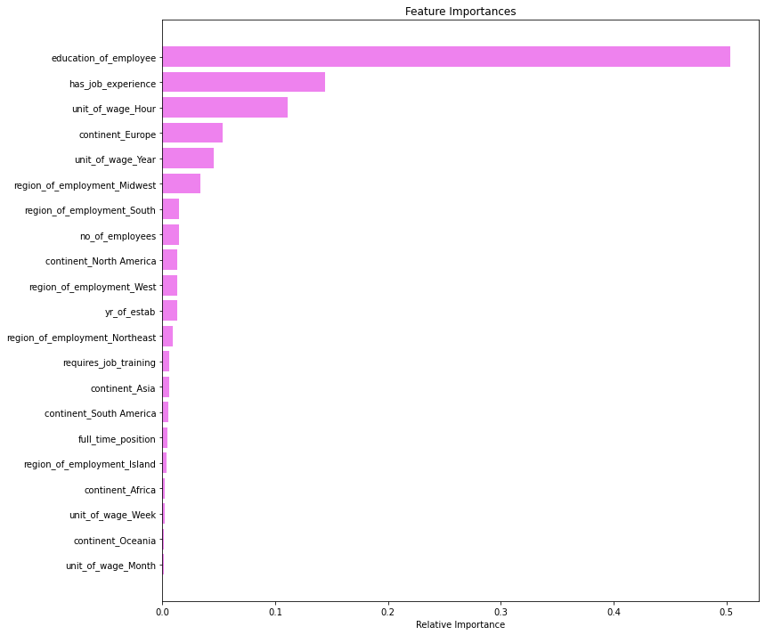

```python
importances = gbc_tuned.feature_importances_
indices = np.argsort(importances)
feature_names = list(X.columns)

plt.figure(figsize=(12,12))
plt.title('Feature Importances')
plt.barh(range(len(indices)), importances[indices], color='violet', align='center')
plt.yticks(range(len(indices)), [feature_names[i] for i in indices])
plt.xlabel('Relative Importance')
plt.show()
```

- The 6 most important features are education of employee, has job experience, unit of wage hour, continent Europe, unit of wage year, and region of employment Midwest.

### Tuned XGBoost

```python
# Choose the type of classifier.
xgb_tuned = XGBClassifier(random_state=1, eval_metric='logloss')

# Grid of parameters to choose from
parameters = {
    "n_estimators": [40,50,60],
    "scale_pos_weight":[1,2,5],
    "subsample":[0.7,0.9,1],
    "learning_rate":[0.02, 0.03,0.04],
    "colsample_bytree":[0.6,0.7,0.8],
    "colsample_bylevel":[0.7,1]
}

# Type of scoring used to compare parameter combinations
scorer = metrics.make_scorer(metrics.f1_score)

# Run the grid search
grid_obj = GridSearchCV(xgb_tuned, parameters,scoring=scorer,cv=5)
grid_obj = grid_obj.fit(X_train, y_train)

# Set the clf to the best combination of parameters
xgb_tuned = grid_obj.best_estimator_

# Fit the best algorithm to the data.
xgb_tuned.fit(X_train, y_train)
```

```
XGBClassifier(base_score=0.5, booster='gbtree', callbacks=None,
              colsample_bylevel=1, colsample_bynode=1, colsample_bytree=0.7,
              early_stopping_rounds=None, enable_categorical=False,
              eval_metric='logloss', gamma=0, gpu_id=-1,
              grow_policy='depthwise', importance_type=None,
              interaction_constraints='', learning_rate=0.03, max_bin=256,
              max_cat_to_onehot=4, max_delta_step=0, max_depth=6, max_leaves=0,
              min_child_weight=1, missing=nan, monotone_constraints='()',
              n_estimators=60, n_jobs=0, num_parallel_tree=1, predictor='auto',
              random_state=1, reg_alpha=0, reg_lambda=1, ...)
```

|  | Accuracy | Recall | Precision | F1 |
| --- | --- | --- | --- | --- |
| Training performance | 0.758971 | 0.89927 | 0.77563 | 0.832886 |

|  | Accuracy | Recall | Precision | F1 |
| --- | --- | --- | --- | --- |
| Testing performance | 0.743721 | 0.889324 | 0.765083 | 0.822538 |

```
Confusion Matrix
```

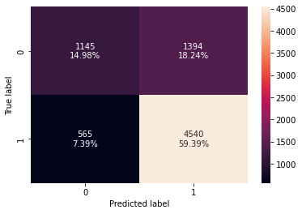

```python
xgb_tuned_estimator_model_train_perf=model_performance_classification_sklearn(xgb_tuned, X_train, y_train,'Training performance')
display(xgb_tuned_estimator_model_train_perf)

xgb_tuned_estimator_model_test_perf=model_performance_classification_sklearn(xgb_tuned, X_test, y_test, 'Testing performance')
display(xgb_tuned_estimator_model_test_perf)

print("\nConfusion Matrix")
confusion_matrix_sklearn(xgb_tuned, X_test, y_test)
```

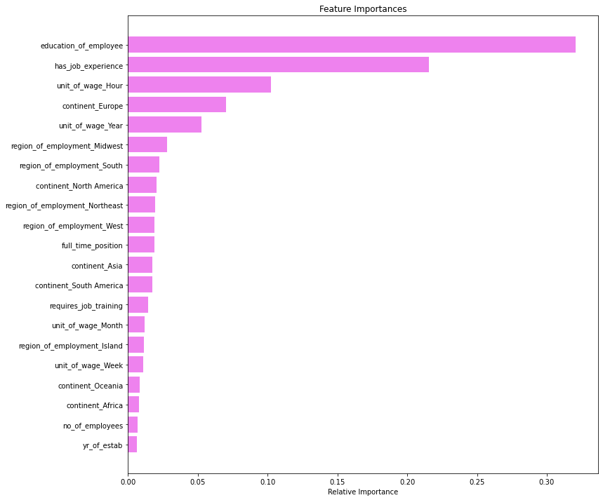

```python
feature_names = X_train.columns
importances = xgb_tuned.feature_importances_
indices = np.argsort(importances)

plt.figure(figsize=(12,12))
plt.title('Feature Importances')
plt.barh(range(len(indices)), importances[indices], color='violet', align='center')
plt.yticks(range(len(indices)), [feature_names[i] for i in indices])
plt.xlabel('Relative Importance')
plt.show()
```

- The feature of top importance is education of employee.
- The next most important feature is has job experience.
- Unit of wage Hour and continent Europe are the 3rd and 4th most important features.
- Other features of importance are unit of wage Year, region of employment Midwest, and region of employment South.
- There are 14 more features of minor importance.

### Stacking Classifier

```python
estimators = [('Random Forest',rf_estimator), ('Adaptive Boosting',abc_tuned)]

final_estimator = gbc_tuned

stacking_classifier= StackingClassifier(estimators=estimators,final_estimator=final_estimator)

stacking_classifier.fit(X_train,y_train)
```

```
StackingClassifier(estimators=[('Random Forest',
                                RandomForestClassifier(class_weight={0: 0.67,
                                                                     1: 0.33},
                                                       max_features=0.1,
                                                       max_samples=0.1,
                                                       n_estimators=250,
                                                       random_state=1)),
                               ('Adaptive Boosting',
                                AdaBoostClassifier(base_estimator=DecisionTreeClassifier(max_depth=1,
                                                                                         random_state=1),
                                                   learning_rate=0.05,
                                                   n_estimators=25,
                                                   random_state=1))],
                   final_estimator=GradientBoostingClassifier(init=AdaBoostClassifier(random_state=1),
                                                              max_features=1,
                                                              random_state=1,
                                                              subsample=0.8))
```

|  | Accuracy | Recall | Precision | F1 |
| --- | --- | --- | --- | --- |
| Training performance | 0.779267 | 0.870226 | 0.812588 | 0.84042 |

|  | Accuracy | Recall | Precision | F1 |
| --- | --- | --- | --- | --- |
| Testing performance | 0.736787 | 0.844466 | 0.779707 | 0.810796 |

```
Confusion Matrix
```

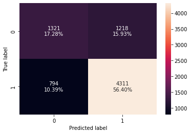

```python
stacking_classifier_model_train_perf=model_performance_classification_sklearn(stacking_classifier, X_train, y_train,'Training performance')
display(stacking_classifier_model_train_perf)

stacking_classifier_model_test_perf=model_performance_classification_sklearn(stacking_classifier, X_test, y_test, 'Testing performance')
display(stacking_classifier_model_test_perf)

print("\nConfusion Matrix")
confusion_matrix_sklearn(stacking_classifier, X_test, y_test)
```

- With this model, recall and f1 for train and test are good, precision is reasonable.
- The training set and test set values are similar.

## Model Performance Comparison and Conclusions

### Comparing all the models

```python
# training performance comparison

models_train_comp_df = pd.concat(
    [dtree_model_train_perf.T,bagging_model_train_perf.T,rf_model_train_perf.T,
    abc_model_train_perf.T, gbc_model_train_perf.T, gbc_init_model_train_perf.T, xgb_model_train_perf.T, dtree_estimator_model_train_perf.T, bagging_estimator_model_train_perf.T,
     rf_estimator_model_train_perf.T, abc_tuned_estimator_model_train_perf.T, gbc_tuned_estimator_model_train_perf.T, xgb_tuned_estimator_model_train_perf.T, stacking_classifier_model_train_perf.T],
    axis=1,
)
models_train_comp_df.columns = [
    "Decision Tree",
    "Bagging Classifier",
    "Random Forest Classifier",
    "AdaBoost Classifier",
    "Gradient Boost Classifier",
    "Gradient Boost with AdaBoost init",
    "XGBoost Classifier",
    "Decision Tree Estimator",
    "Bagging Estimator",
    "Random Forest Estimator",
    "AdaBoost Estimator",
    "Gradient Boost Estimator",
    "XGBoost Estimator",
    "Stacking Classifier"
]
print("Training performance comparison:")
display(models_train_comp_df)


# test performance comparison

models_test_comp_df = pd.concat(
    [dtree_model_test_perf.T,bagging_model_test_perf.T,rf_model_test_perf.T,
    abc_model_test_perf.T, gbc_model_test_perf.T, gbc_init_model_test_perf.T, xgb_model_test_perf.T, dtree_estimator_model_test_perf.T, bagging_estimator_model_test_perf.T,
     rf_estimator_model_test_perf.T, abc_tuned_estimator_model_test_perf.T, gbc_tuned_estimator_model_test_perf.T, xgb_tuned_estimator_model_test_perf.T, stacking_classifier_model_test_perf.T],
    axis=1,
)
models_test_comp_df.columns = [
    "Decision Tree",
    "Bagging Classifier",
    "Random Forest Classifier",
    "AdaBoost Classifier",
    "Gradient Boost Classifier",
    "Gradient Boost with AdaBoost init",
    "XGBoost Classifier",
    "Decision Tree Estimator",
    "Bagging Estimator",
    "Random Forest Estimator",
    "AdaBoost Estimator",
    "Gradient Boost Estimator",
    "XGBoost Estimator",
    "Stacking Classifier"
]
print("Test performance comparison:")
display(models_test_comp_df)
```

```
Training performance comparison:
```

|  | Decision Tree | Bagging Classifier | Random Forest Classifier | AdaBoost Classifier | Gradient Boost Classifier | Gradient Boost with AdaBoost init | XGBoost Classifier | Decision Tree Estimator | Bagging Estimator | Random Forest Estimator | AdaBoost Estimator | Gradient Boost Estimator | XGBoost Estimator | Stacking Classifier |
| --- | --- | --- | --- | --- | --- | --- | --- | --- | --- | --- | --- | --- | --- | --- |
| Accuracy | 0.999888 | 0.982619 | 0.999888 | 0.737273 | 0.755943 | 0.755607 | 0.820700 | 0.716641 | 0.667919 | 0.790928 | 0.691803 | 0.739852 | 0.758971 | 0.779267 |
| Recall | 0.999832 | 0.983128 | 0.999916 | 0.886930 | 0.879963 | 0.879627 | 0.920255 | 0.779569 | 1.000000 | 0.918241 | 0.971628 | 0.911861 | 0.899270 | 0.870226 |
| Precision | 1.000000 | 0.990779 | 0.999916 | 0.759871 | 0.781963 | 0.781782 | 0.829839 | 0.792744 | 0.667919 | 0.798817 | 0.691706 | 0.751609 | 0.775630 | 0.812588 |
| F1 | 0.999916 | 0.986939 | 0.999916 | 0.818499 | 0.828074 | 0.827823 | 0.872711 | 0.786101 | 0.800901 | 0.854376 | 0.808113 | 0.824016 | 0.832886 | 0.840420 |

```
Test performance comparison:
```

|  | Decision Tree | Bagging Classifier | Random Forest Classifier | AdaBoost Classifier | Gradient Boost Classifier | Gradient Boost with AdaBoost init | XGBoost Classifier | Decision Tree Estimator | Bagging Estimator | Random Forest Estimator | AdaBoost Estimator | Gradient Boost Estimator | XGBoost Estimator | Stacking Classifier |
| --- | --- | --- | --- | --- | --- | --- | --- | --- | --- | --- | --- | --- | --- | --- |
| Accuracy | 0.657509 | 0.691130 | 0.700026 | 0.734956 | 0.744505 | 0.743721 | 0.728414 | 0.715594 | 0.667844 | 0.732601 | 0.689953 | 0.728153 | 0.743721 | 0.736787 |
| Recall | 0.736533 | 0.768462 | 0.806464 | 0.887561 | 0.875220 | 0.876004 | 0.855632 | 0.782370 | 1.000000 | 0.883643 | 0.971988 | 0.905779 | 0.889324 | 0.844466 |
| Precision | 0.747069 | 0.768914 | 0.759314 | 0.757312 | 0.772476 | 0.771300 | 0.765376 | 0.789796 | 0.667844 | 0.756752 | 0.690221 | 0.743289 | 0.765083 | 0.779707 |
| F1 | 0.741764 | 0.768688 | 0.782179 | 0.817280 | 0.820645 | 0.820325 | 0.807991 | 0.786066 | 0.800847 | 0.815290 | 0.807223 | 0.816528 | 0.822538 | 0.810796 |

- The Decision Tree, Bagging Classifier, Random Forest Classifier, and XGBoost Classifier all overfit the training data.
- The Random Forest Estimator also overfit the training data, but to a lesser extent.
- The remaining 9 models had similar performance metric outcomes between each of their training and test sets indicating the overfitting was not an issue.
- The remaining 9 models had test f1 scores in the 0.79 - 0.82 range
- Of the remaining 9 models, 2 models: Bagging Estimator and AdaBoost Estimator had very high recall scores with lower precision. These models predicted that all or close to all of the applicants would be certified.
- The remaining 7 models (AdaBoost Classifier, Gradient Boost Classifier, Gradient boost with AdaBoost init, Decision Tree Estimator, Gradient Boost Estimator, and XGBoost Estimator, and Stacking Classifier) had a slightly more balanced recall and precision scores with recall ranging from 0.78 to 0.91 and precision ranging from 0.74 to 0.79. The models resulting in precision on the high end of this range had recall on the low end of this range and vice versa.
- Of the remaining 7 models, the three with the highest f1 scores will be considered as the best models.
- The models with the highest f1 are GradientBoost Classifier, Gradient Boost with AdaBoost initializer, and XGBoost Estimator.
- The feature importances of these models are shown below.

### Gradient Boost Feature Importance

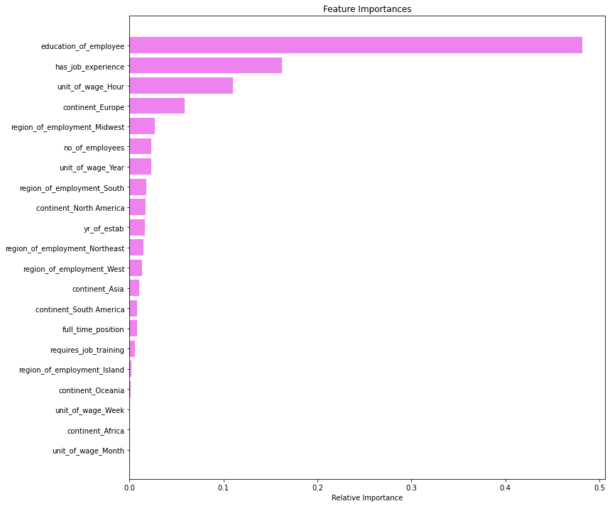

```python
feature_names = X_train.columns
importances = gbc.feature_importances_
indices = np.argsort(importances)

plt.figure(figsize=(12,12))
plt.title('Feature Importances')
plt.barh(range(len(indices)), importances[indices], color='violet', align='center')
plt.yticks(range(len(indices)), [feature_names[i] for i in indices])
plt.xlabel('Relative Importance')
plt.show()
```

- The top 5 feature importances are education of employee, has job experience, unit of wage Hour, continent Europe, and region of employment Midwest.

### Gradient Boost with AdaBoost Initiator Feature Importance

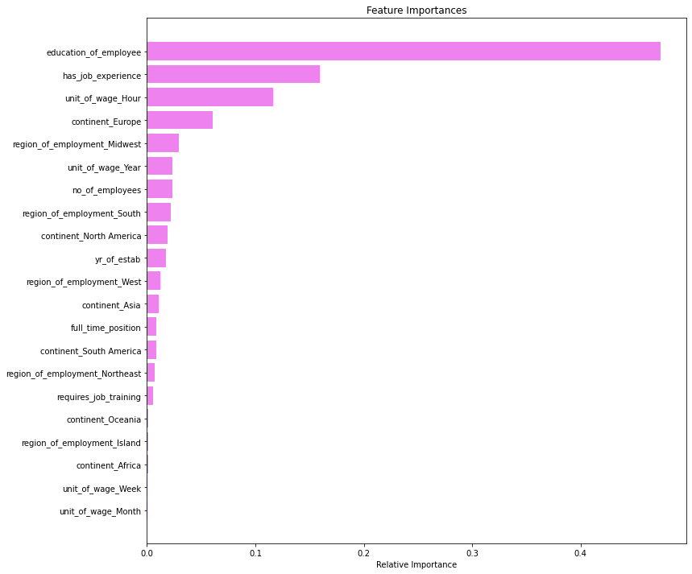

```python
feature_names = X_train.columns
importances = gbc_init.feature_importances_
indices = np.argsort(importances)

plt.figure(figsize=(12,12))
plt.title('Feature Importances')
plt.barh(range(len(indices)), importances[indices], color='violet', align='center')
plt.yticks(range(len(indices)), [feature_names[i] for i in indices])
plt.xlabel('Relative Importance')
plt.show()
```

- The top 5 feature importances are education of employee, has job experience, unit of wage Hour, continent Europe, and region of employment Midwest.

### XGBoost Estimator Feature Importance

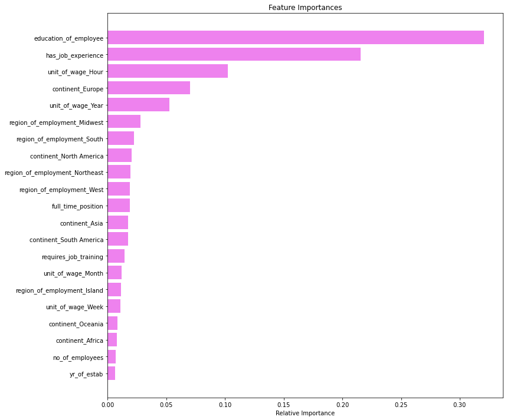

```python
feature_names = X_train.columns
importances = xgb_tuned.feature_importances_
indices = np.argsort(importances)

plt.figure(figsize=(12,12))
plt.title('Feature Importances')
plt.barh(range(len(indices)), importances[indices], color='violet', align='center')
plt.yticks(range(len(indices)), [feature_names[i] for i in indices])
plt.xlabel('Relative Importance')
plt.show()
```

- The top 5 feature importances are education of employee, has job experience, unit of wage Hour, continent Europe, and unit of wage Year.